# Demonstrações Contábeis, Impostos e Fluxo de Caixa

Ross et al. (2022), Cap 02

Marcelo S. Perlin

EA-UFRGS

17/08/2026

# Introdução a Demontrações Financeiras

## O que são demonstrações financeiras?

> São relatórios estruturados que resumem o desempenho econômico e a saúde financeira de uma organização.
- Principais tipos:
  - Balanço Patrimonial (BP)
  - Demonstração do Resultado do Exercício (DRE)
  - Demonstração dos Fluxos de Caixa (DFC)
- **Objetivo:** Fornecer dados quantitativos para apoiar a tomada de decisão de investidores, credores, gestores e órgãos reguladores.
- Padronização: Seguem normas contábeis rigorosas (como IFRS e pronunciamentos do CPC) para garantir transparência, auditoria e comparabilidade no mercado.

## Por que avaliar DFs?

- **Controle Interno**
  - Permite analisar a capacidade de gerar caixa e tomar novas dívidas
  - Avaliação de desempenho: remuneração de executivos e comparação entre divisões da empresa
  - Planejar o futuro: guia para estimar fluxos de caixa futuros
- **Controle externo**
  - Permite análise da qualidade das operações da empresa
  - Permite análise da solvência da empresa
    - análise de crédito
    - análise de fornecimento

## Principais documentos

- Balanço Patrimonial (BP)
- Demonstrativo de resultados (DRE)
- Demonstrativo de fluxo de caixa (DFC)
- Demonstração de mutações do patrimônio líquido (DMPL) (NAO VISTO EM AULA)
- Demonstração do Valor Adicionado (DVA) (NAO VISTO EM AULA)

# Balanço Patrimonial (BP)

## Introdução

> O balanço patrimonial é uma fotografia dos ativos e obrigações em determinado momento.

Características:

- Ativos (ou contas) do BP são listados em ordem decrescente de sua liquidez
- Identidade do balanço patrimonial (resultado do método de partidas dobradas):

$$Ativo Total = Passivo Total$$

$$Passivo Total = Obrigações + CapitalDosSócios$$

## Capital Circulante Líquido e a liquidez da empresa

> O CCL mede a capacidade da empresa, no curto prazo, de pagar suas contas.

$$CCL = AtivoCirculante – PassivoCirculante$$

- Positivo quando o caixa a ser recebido nos próximos 12 meses excede ao caixa que deverá ser pago nesse período
- Geralmente é positivo em empresas com boa saúde financeira
- Empresas com liquidez têm menor probabilidade de enfrentar problemas financeiros
- Um alto CCL, porém, pode indicar um superinvestimento da empresa em recursos ociosos

## O balanço patrimonial

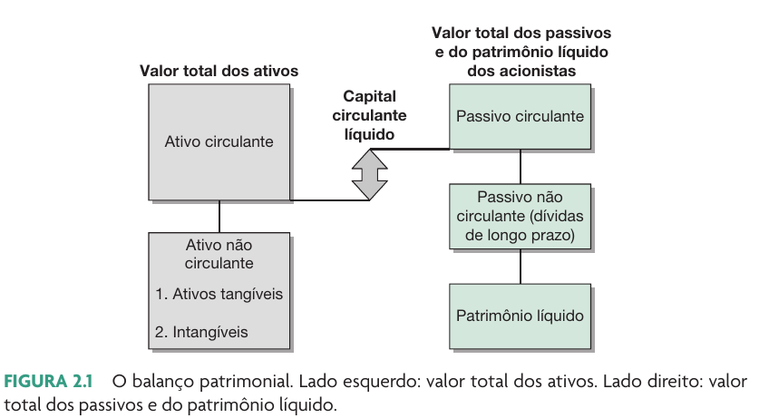

Extraído de Ross et al. (2022), página 25

## Valor de mercado vs. Valor contábil

> O balanço patrimonial informa o valor contábil dos ativos, das obrigações e do capital próprio.
- Valor de mercado é o preço pelo qual ativos, obrigações e capital próprio podem efetivamente ser vendidos.
- Valor de mercado e valor contábil, com frequência, diferem muito. Por que?
- Qual dos dois valores é mais importante para o processo decisório?

## Exemplo 2.2 A Cia Klingon

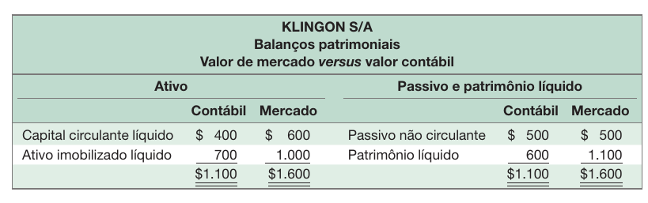

Extraído de Ross et al. (2022), página 29

## Sistema DFP da B3

> A B3 disponibliza todos os demonstrativos anuais das empresas listadas na bolsa em seu sistema DFP (Demonstrativo Financeiros Padronizados)

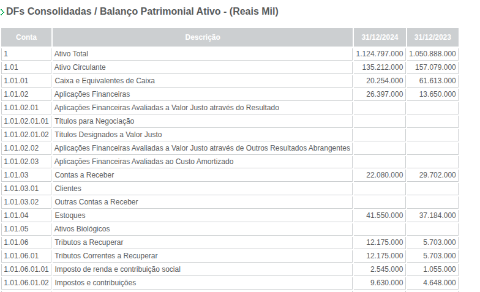

Amostra DFP

[Link B3](https://www.b3.com.br/pt_br/produtos-e-servicos/negociacao/renda-variavel/empresas-listadas.htm)

## Pontos importantes em um BP

### Ativo

- Proporção de investimento do ativo não circulante/imobilizado (AnC) em relação ao ativo total
- Valor em estoque e tipo de estoque
- Valores em contas a receber

### Passivo

- Proporção de dívidas por tipo (longo/curto)
- Composição do PL (existência de lucros acumulados)

**Important**

As propriedades do BP são coerentes com o discurso da administração?

## O caso OGX

> Do IPO recorde à maior Recuperação Judicial da América Latina (2013).
- Captação de R$ 6,7 bilhõe em 2008 (maior abertura de capital do Brasil até então).
- Tese de Investimento: Monetização de ativos pré-operacionais (Exploração & Produção).
- Valuation: Baseado em “recursos prospectivos” (estimativas de óleo) e não em fluxo de caixa descontado de produção real.
- Market Cap: A OGX chegou a valer mais de R$ 75 bilhões em 2010.

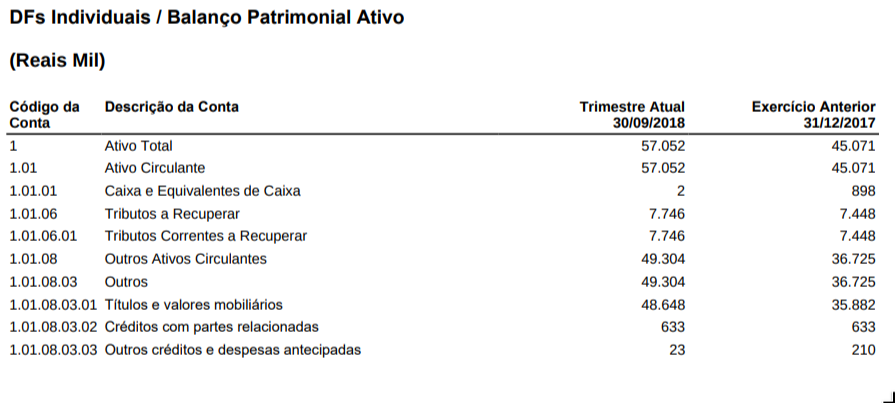

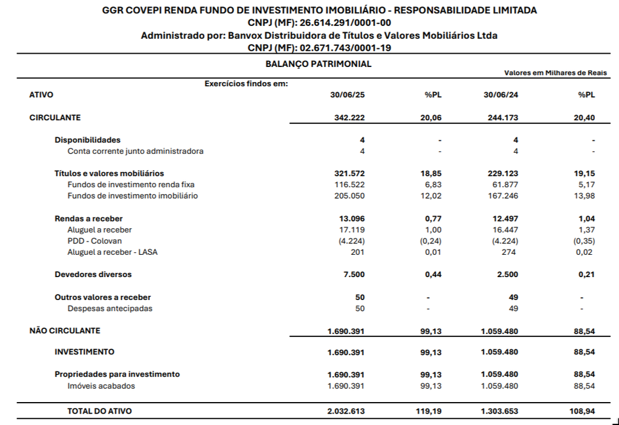

Origem: [site da empresa](https://www.ggrc11.com.br/documentos)

# A demonstração de resultados (DRE)

## Introdução

> O DRE é um vídeo das operações da empresa num período específico de tempo.
- Geralmente são apresentadas as receitas e então deduzidas as despesas associadas aos produtos ou serviços e as despesas do período.
- A DRE obedece ao **regime de competência** (e não regime de caixa).

## O regime de competência

> Sob o método de competência, os efeitos financeiros das transações e eventos são reconhecidos nos períodos nos quais ocorrem, independentemente de terem sido efetivamente recebidos ou pagos. (Ross et al. 2022)

Exemplo:

- Você vende um produto em dezembro, mas o cliente só paga em janeiro. No regime de competência, a receita será registrada em dezembro, mesmo que o dinheiro só entre em janeiro.
- Você compra um material em dezembro, mas só paga em janeiro. No regime de competência, a despesa será registrada em dezembro, mesmo que o dinheiro só saia em janeiro.

## Princípios do Regime de Competência

> **Princípio da Realização das Receitas**: Uma receita é reconhecida nos livros da empresa quando os produtos ou serviços são transferidos ao cliente.

> **Princípio do Confronto das Despesas com as Receitas e com os Períodos Contábeis**: todas as despesas associáveis a um produto ou serviço são com eles confrontadas; os consumos de ativos (atuais ou futuros) que não puderam ser associados à receita do período nem às dos períodos futuros, devem ser descarregados como despesa do período em que ocorrerem.

## DRE da Brasil S/A

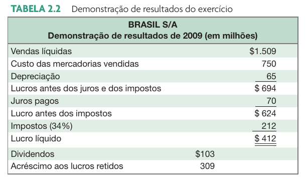

Extraído de Ross et al. (2022), página 30

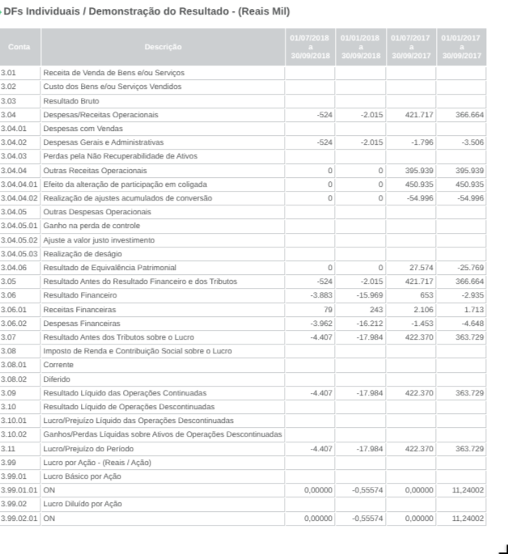

## DRE do GGRC11

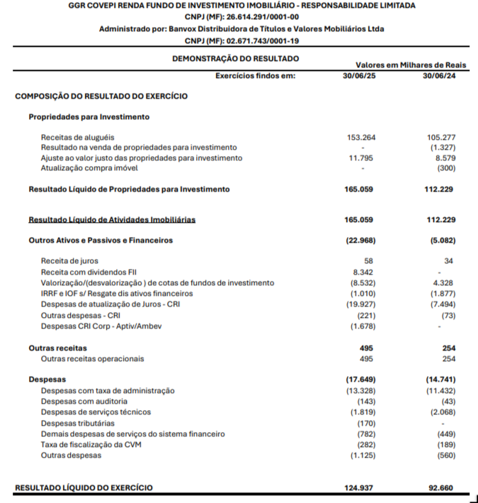

Origem: [site da empresa](https://www.ggrc11.com.br/documentos)

# Demonstração de Fluxos de Caixa (DFC)

## Introdução

> Documento que resume as fontese os usos de caixa, conciliando a variação da conta caixa com os fluxos operacionais, investimento e financiamento.

Variações apresentadas em três grandes categorias:

- Atividades Operacionais: o lucro líquido e outras variações nas contas circulantes
- Atividades de Investimento: as variações nos ativos imobilizados
- Atividades de Financiamento: as variações em empréstimos e dívidas, títulos de dívida a pagar, passivos não circulantes, contas do patrimônio líquido, e dividendos.

## Exemplo de DFC

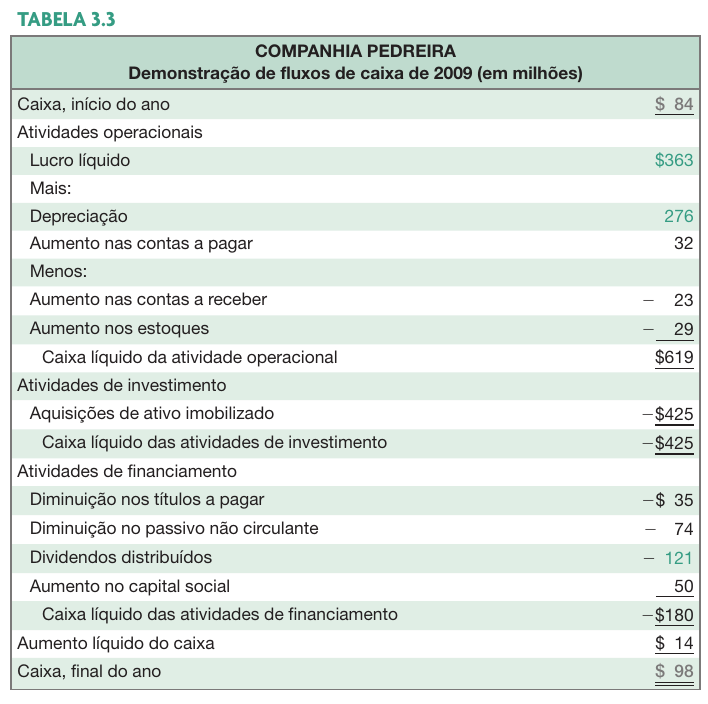

Retirado de Ross et al. (2022) página 56

## DFC do GGRC11

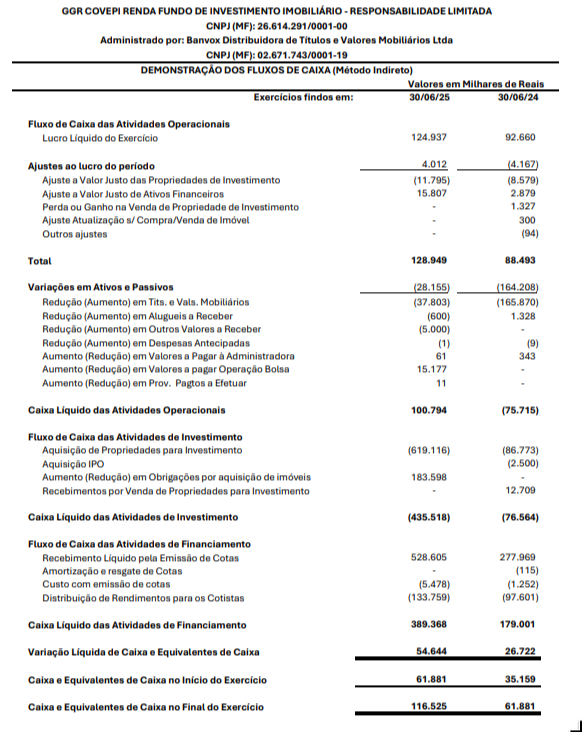

Origem: [site da empresa](https://www.ggrc11.com.br/documentos)

## Um exercício sobre fluxo de caixa

### Ativo e Passivo

#### Contas circulantes

2009: AC = 4.400; PC = 1.500

2008: PC = 3.500; PC = 1.200

#### Ativo Imobilizado e Depreciação

2009: Imobilizado = 3.400;

2008: Imobilizado = 3.100

Despesas de depreciação = 400

#### Passivo Não Circulante e PL (Lucros Retidos não informados)

2009: PNC = 4.000; Capital e reservas = 400

2008: PNC = 3.950; Capital e reservas = 400

## Demonstração de Resultados do Exercício

LAJIR = 2.000; IR = 300

Despesas de juros = 350

Dividendos = 500

## Resposta Exercício

**Com base nas informações anteriores, calcule o FCA**

FCO = 2000 + 400 – 300 = 2100

Gastos de capital = 3400 – 3100 + 400 = 700

Variação no CCL = (4400 – 1500) – (3500 – 1200) = 600

FCA = 2100 – 700 - 600 = 800

FC para os Credores = 350 – (4000 – 3950) = 300

FC para os Acionistas = 500

FCA = 300 + 500 = 800

# Documentos Financeiros na vida real

## Monark

- A empresa foi fundada em abril de 1948 com a denominação de Monark Indústria e Comércio Ltda
- Inicialmente, atuava como importadora e montadora. Em 1951 passou a ser fabricante de bicicletas.
- Modelos icônicos: Monark Monareta, Monark Barra Circular, Monark BMX
- Produção anual de mais de 500 mil bicicletas

## Como a Monark ganha dinheiro?

Balanço Patrimonial - BICICLETAS MONARK S.A. | Final 2024

Valores em Milhares

| CD_CONTA | DS_CONTA | VALOR |
| --- | --- | --- |
| 1 | Ativo Total | R$ 232.040,00 |
| 1.01 | Ativo Circulante | R$ 178.493,00 |
| 1.01.01 | Caixa e Equivalentes de Caixa | R$ 164.596,00 |
| 1.01.02 | Aplicações Financeiras | R$ 0,00 |
| 1.01.03 | Contas a Receber | R$ 4.708,00 |
| 1.01.04 | Estoques | R$ 7.185,00 |
| 1.01.05 | Ativos Biológicos | R$ 0,00 |
| 1.01.06 | Tributos a Recuperar | R$ 1.901,00 |
| 1.01.07 | Despesas Antecipadas | R$ 103,00 |
| 1.01.08 | Outros Ativos Circulantes | R$ 0,00 |
| 1.02 | Ativo Não Circulante | R$ 53.547,00 |
| 1.02.01 | Ativo Realizável a Longo Prazo | R$ 48.770,00 |
| 1.02.02 | Investimentos | R$ 0,00 |
| 1.02.03 | Imobilizado | R$ 4.777,00 |
| 1.02.04 | Intangível | R$ 0,00 |

Demonstrativo de Resultados - BICICLETAS MONARK S.A. | Final 2024

Valores em Milhares

| CD_CONTA | DS_CONTA | VALOR |
| --- | --- | --- |
| 3.01 | Receita de Venda de Bens e/ou Serviços | R$ 15.064,00 |
| 3.02 | Custo dos Bens e/ou Serviços Vendidos | R$ -10.451,00 |
| 3.03 | Resultado Bruto | R$ 4.613,00 |
| 3.04 | Despesas/Receitas Operacionais | R$ -2.176,00 |
| 3.05 | Resultado Antes do Resultado Financeiro e dos Tributos | R$ 2.437,00 |
| 3.06 | Resultado Financeiro | R$ 17.335,00 |
| 3.07 | Resultado Antes dos Tributos sobre o Lucro | R$ 19.772,00 |
| 3.08 | Imposto de Renda e Contribuição Social sobre o Lucro | R$ -4.736,00 |
| 3.09 | Resultado Líquido das Operações Continuadas | R$ 15.036,00 |
| 3.10 | Resultado Líquido de Operações Descontinuadas | R$ 0,00 |
| 3.11 | Lucro/Prejuízo do Período | R$ 15.036,00 |
| 3.99 | Lucro por Ação - (Reais / Ação) | R$ 0,00 |

# Impostos

> A única coisa certa quanto a tributos é que eles sempre irão existir e sempre estarão mudando (Ross et al. 2022)

## Alíquota marginal vs. alíquota média

**Alíquota tributária marginal**: a percentagem de impostos paga sobre o próximo real faturado

**Alíquota tributária média**: a conta de tributos dividida pelo lucro tributável

## IR em USA

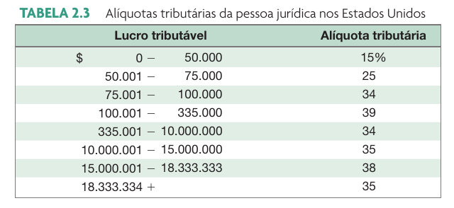

Extraído de Ross et al. (2022), página 34

## IR no Brasil

Alíquotas de Imposto de Renda sobre lucro no Brasil (2026)

Tabela válida para pessoa jurídica e apenas impostos federais

| Valor do Lucro Tributável | IRPJ | CSLL | Soma |
| --- | --- | --- | --- |
| Menor que R$ 240.000,00 | 15,00% | 9,00% | 24,00% |
| Maior ou igual a R$ 240.000,00 | 25,00% | 9,00% | 34,00% |

## Exemplo: Alíquota marginal X Alíquota média

Suponha que sua empresa tenha um lucro tributável de R$ 1.000.000,00

- Qual é o IR e CSLL devido?
- Qual é a alíquota média?
- Qual é a alíquota marginal?

> Se você está avaliando um projeto que vai aumentar o lucro tributável em mais de R$ 500.000,00, qual é a alíquota tributária que você deveria utilizar em sua análise?

## Cálculo IR

Lubro Tributável: R$ 1.000.000,00

24,00% de R$ 240.000,00: R$ 57.600,00

34,00% de R$ 760.000,00: R$ 258.400,00

Total de IR: R$ 316.000,00

Alíquota marginal = 34,00%

Alíquota média = 31,60%

## Referências

Ross, Stephen, Randolph Westerfield, Bradford Jordan, et al. 2022. *Fundamentos de Administração Financeira*. Bookman Editora.